# 5 Hierarchical models with latent variables

Jan Smyčka

08/01/2023

Here we will go through a simple hierarchical model with measurement error.

# Data

Imagine you were asked to measure sizes of the trees in tree avenue going to the lake. We would like to know whether the sizes of the trees increase with humidity. However, trees are difficult to measure. For this reason you have decided to measure every tree multiple times, using the triangulation - it is not precise, but it should give a reasonable idea on how high the trees are.

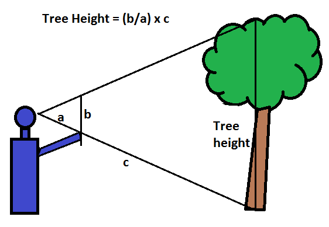

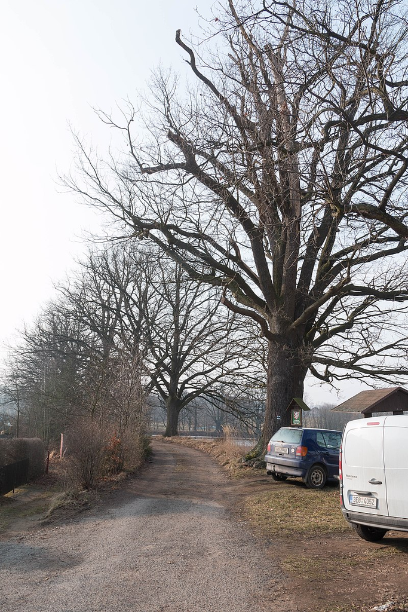

We can load the data and the rethinking package.

We can see it is two datasets, one containing all measurements for all trees, another one smaller (we’ll talk about it later).

```r
scdata
```

```
## $observed
##  [1]  98.51367 101.80741  99.63854 100.29765 102.08154 102.65499  99.35954
##  [8]  99.17081 101.78516 100.69613 104.29297 107.38552 104.95295 100.83970
## [15] 100.57027 101.52617 108.30205 106.73836 103.77992 104.01809 101.90837
## [22] 105.71269 105.90757 105.84192 103.30059 105.67553 103.50968 103.59292
## [29] 105.73007 106.46095 105.03624 104.80662 105.51613 105.11852 107.12571
## [36] 105.95968
##
## $humidity
## [1] 0.0 0.2 0.4 0.6 0.8 1.0
##
## $humidityex
##  [1] 0.0 0.2 0.2 0.2 0.2 0.4 0.4 0.4 0.4 0.4 0.6 0.6 0.6 0.8 0.8 0.8 0.8 0.8 0.8
## [20] 1.0 1.0 1.0 1.0 1.0 1.0 1.0 1.0 1.0 1.0 1.0 1.0 1.0 1.0 1.0 1.0 1.0
##
## $id
##  [1] 1 2 2 2 2 3 3 3 3 3 4 4 4 5 5 5 5 5 5 6 6 6 6 6 6 6 6 6 6 6 6 6 6 6 6 6
```

```r
sc1data
```

```
## $observed1
## [1]  98.51367 101.80741 102.65499 104.29297 100.83970 104.01809
##
## $humidity
## [1] 0.0 0.2 0.4 0.6 0.8 1.0
##
## $id
## [1] 1 2 3 4 5 6
```

Let’s plot the data in the first dataset, height observations against humidity. we see that there is another problem - it is easy to triangulate from the lake, so the trees in more humid environment were triangulated more times.

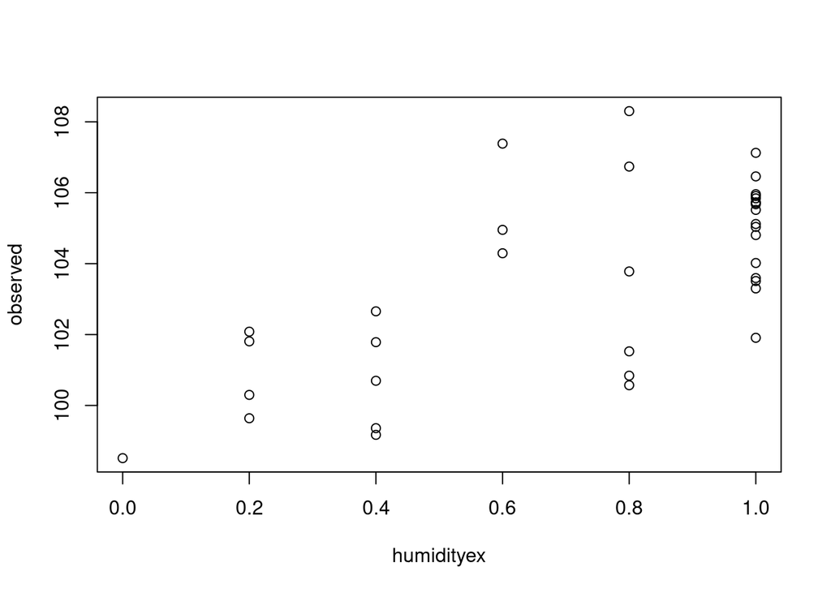

```r
plot(observed~humidityex,data=scdata)
```

If we ignored everything and fitted a frequentist linear model, this would be significant. Can you say why this approach is wrong?

```r
summary(lm(observed~humidityex,data=scdata))
```

```
##
## Call:
## lm(formula = observed ~ humidityex, data = scdata)
##
## Residuals:
##     Min      1Q  Median      3Q     Max
## -3.4049 -1.1876  0.0388  0.9974  4.5346
##
## Coefficients:
##             Estimate Std. Error t value Pr(>|t|)
## (Intercept)  99.4783     0.8283  120.10  < 2e-16 ***
## humidityex    5.6211     1.0390    5.41 5.04e-06 ***
## ---
## Signif. codes:  0 '***' 0.001 '**' 0.01 '*' 0.05 '.' 0.1 ' ' 1
##
## Residual standard error: 1.949 on 34 degrees of freedom
## Multiple R-squared:  0.4626, Adjusted R-squared:  0.4468
## F-statistic: 29.27 on 1 and 34 DF,  p-value: 5.035e-06
```

# Model

For modeling this system we can use latent variables. These are variables that are important for our thinking about the processes that generated the data, but they are not directly observable. Such as real height of the trees - we only have its estimates using triangulation, but not the exact values. Importantly, each tree can be triangulated with different precision dependent e.g. on shape of its crown.

```r
scmodel=alist(
  observed ~ dnorm(realsize[id], sigmam[id]),
  realsize[id] ~ dnorm(mu, sigma),
  mu <- alpha + beta*humidity,

  sigma ~ dunif(0,1000),
  sigmam[id] ~ dunif(0,1000),
  alpha ~ dnorm(0, 100),
  beta ~ dnorm(0,100)

)
```

We can fit the model.

```r
scposterior=ulam(scmodel,
                 data=scdata,iter = 5000)
```

Explore the estimates.

```r
precis(scposterior)
```

```
## 12 vector or matrix parameters hidden. Use depth=2 to show them.
```

```
##            mean       sd       5.5%      94.5%    n_eff      Rhat
## sigma  2.176094 2.536308  0.3289463   6.370058 215.9065 0.9996359
## alpha 99.454698 2.899659 95.3919659 103.335696 568.1889 1.0015041
## beta   5.696192 4.576737  0.2527883  11.933099 397.4292 1.0042784
```

There are multiple levels of parameters.

```r
precis(scposterior, depth=2)
```

```
##                   mean          sd        5.5%      94.5%     n_eff      Rhat
## realsize[1]  99.226175   4.0186576  94.3091859 104.331788  519.8098 0.9996170
## realsize[2] 100.787756   0.9931629  99.2958448 102.307529 1039.9481 1.0002472
## realsize[3] 101.137843   0.9815249  99.7391952 102.593692  618.7989 0.9996600
## realsize[4] 103.956154   2.2231338 101.5531692 106.864923  470.6122 1.0046895
## realsize[5] 103.813712   1.2591904 101.8878095 105.881953 1509.3924 0.9997085
## realsize[6] 105.015746   0.3820387 104.4150821 105.584584  788.0867 1.0016407
## sigma         2.176094   2.5363082   0.3289463   6.370058  215.9065 0.9996359
## sigmam[1]   143.416779 217.7293631   1.2044155 641.569309  923.8919 1.0010239
## sigmam[2]     2.200303   1.6596482   0.8640810   5.327213  316.2825 1.0014444
## sigmam[3]     2.223231   1.1828530   1.1040960   4.196447  968.6477 1.0022276
## sigmam[4]     5.637905  12.1214888   1.3046335  15.226504  584.4905 1.0011474
## sigmam[5]     4.107437   1.8846891   2.3288245   7.093218 1207.3521 1.0002647
## sigmam[6]     1.444117   0.2931392   1.0785227   1.964752  929.8206 1.0001530
## alpha        99.454698   2.8996586  95.3919659 103.335696  568.1889 1.0015041
## beta          5.696192   4.5767372   0.2527883  11.933099  397.4292 1.0042784
```

Explore the convergence.

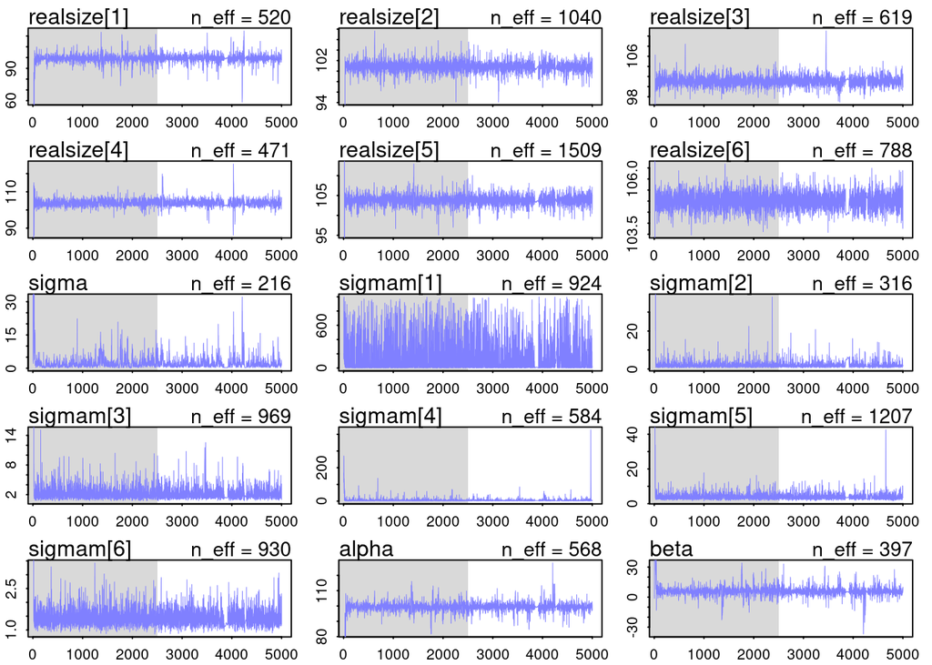

```r
traceplot(scposterior)
```

And plot the mean estimate and credibility lines.

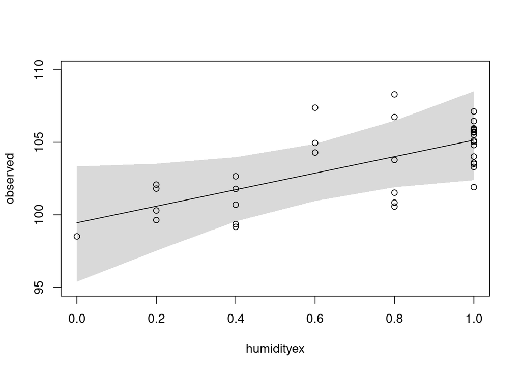

```r
yexpsc=link(scposterior)

yexpmeansc=apply(yexpsc,2, mean)
yexpPIsc=apply(yexpsc,2, PI)

plot(observed~humidityex, data=scdata, ylim=c(95,110))
lines(scdata$humidity , yexpmeansc)
shade(yexpPIsc , scdata$humidity)
```

# Complication and example 1

You are a particularly lazy researcher. Instead of triangulating every tree multiple times, you only did it once. How does it change the parameter inference? You can go explore it yourself.

```r
sc1data
```

```
## $observed1
## [1]  98.51367 101.80741 102.65499 104.29297 100.83970 104.01809
##
## $humidity
## [1] 0.0 0.2 0.4 0.6 0.8 1.0
##
## $id
## [1] 1 2 3 4 5 6
```

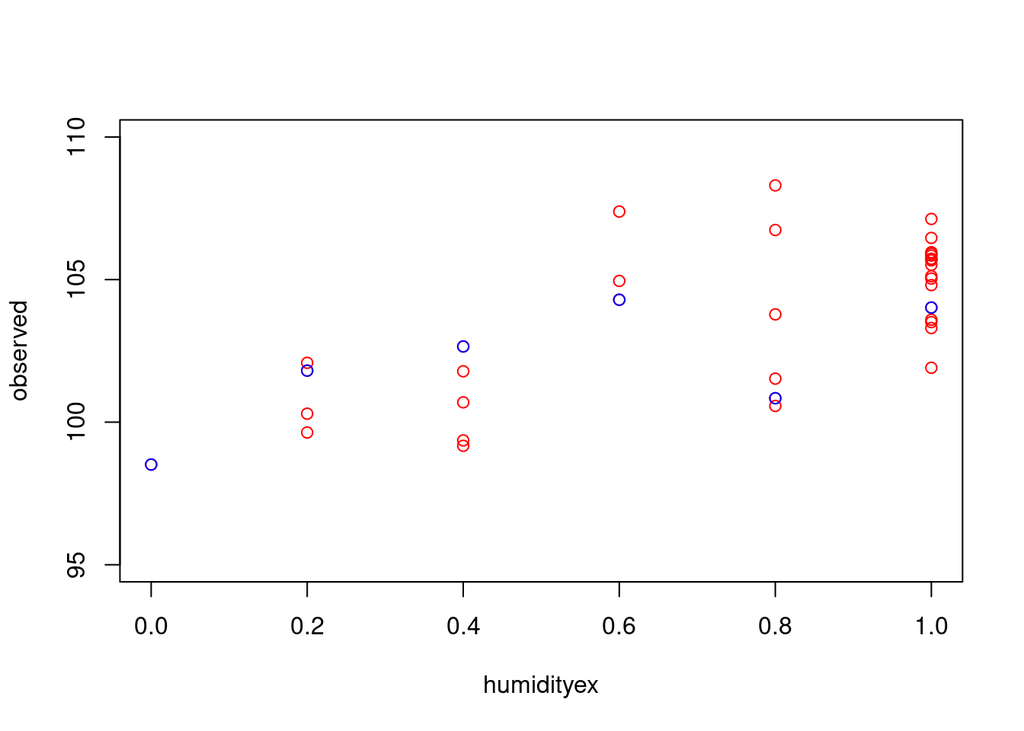

```r
plot(observed~humidityex, data=scdata, col="red", ylim=c(95,110))
points(observed1~humidity, data=sc1data, col="blue")
```

First one can fit the same model as before.

```r
sc1model=alist(
  observed1 ~ dnorm(realsize[id], sigmam[id]),
  realsize[id] ~ dnorm(mu, sigma),
  mu <- alpha + beta*humidity,

  sigma ~ dunif(0,1000),
  sigmam[id] ~ dunif(0,1000),
  alpha ~ dnorm(0, 100),
  beta ~ dnorm(0,100)

)
```

And fit it.

```r
sc1posterior=ulam(sc1model,
                 data=sc1data,iter = 5000)
```

You can see that all the estimates, including alpha and beta, are really poorly estimated. This is because we do not know sigmam values and our data contain almost no information to estimate it. So we do not know how much we can “trust” our points.

```r
precis(sc1posterior)
```

```
## 12 vector or matrix parameters hidden. Use depth=2 to show them.
```

```
##           mean        sd      5.5%    94.5%     n_eff     Rhat
## sigma 83.54497 105.20424   3.01515 272.5267  72.46944 1.018030
## alpha 56.95221  63.97188 -53.07162 151.1024 732.17392 1.002491
## beta  29.24508  75.96837 -96.85447 140.3897 248.68293 1.012958
```

```r
precis(sc1posterior, depth=2)
```

```
##                  mean        sd        5.5%    94.5%      n_eff      Rhat
## realsize[1]  62.19969 100.28713  -90.648071 199.1907  770.70158 0.9998094
## realsize[2]  67.33289 110.20604 -114.892610 210.4590  626.33227 1.0006853
## realsize[3]  76.67841 108.00825  -68.919580 210.6121  861.89216 0.9996068
## realsize[4]  83.48141  98.96976  -79.570125 210.0405 1000.07177 1.0000167
## realsize[5]  87.72616 108.00454  -85.862200 239.4954  853.51717 0.9996212
## realsize[6]  88.62034 105.66867  -96.138473 237.5798  840.04718 1.0029565
## sigma        83.54497 105.20424    3.015150 272.5267   72.46944 1.0180304
## sigmam[1]   287.38243 253.53733   15.713479 821.5669  246.25531 1.0249491
## sigmam[2]   279.01673 255.46269   18.520652 821.6745  286.32166 1.0095770
## sigmam[3]   252.74546 257.77365   14.144193 792.8551   77.16052 1.0330488
## sigmam[4]   305.16768 249.90773   19.725238 820.5976  606.70386 0.9999455
## sigmam[5]   267.04755 278.06819    4.010567 842.1792   54.74986 1.0162246
## sigmam[6]   360.28891 268.71314   25.457170 818.1323   60.27564 1.0161850
## alpha        56.95221  63.97188  -53.071615 151.1024  732.17392 1.0024911
## beta         29.24508  75.96837  -96.854470 140.3897  248.68293 1.0129584
```

Also the convergence is not great, especially for sigmas.

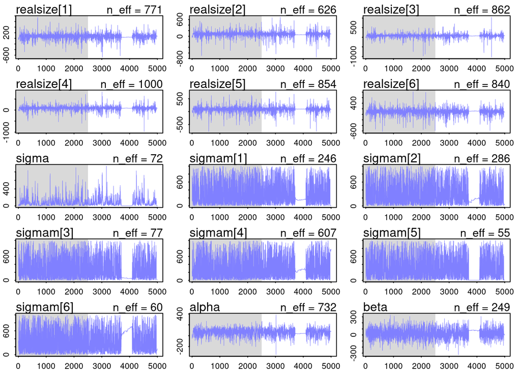

```r
traceplot(sc1posterior)
```

The parameter imprecision is clearly visible on the predictions of expected real tree height values.

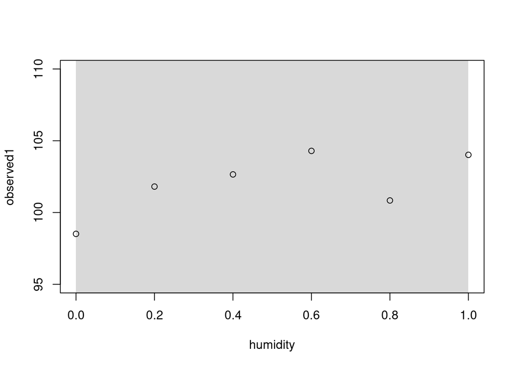

```r
yexpsc1=link(sc1posterior)

yexpmeansc1=apply(yexpsc1,2, mean)
yexpPIsc1=apply(yexpsc1,2, PI)

plot(observed1~humidity, data=sc1data, ylim=c(95,110))
lines(sc1data$humidity , yexpmeansc1)
shade(yexpPIsc1 , sc1data$humidity)
```

The prediction lines are completely out of the data.

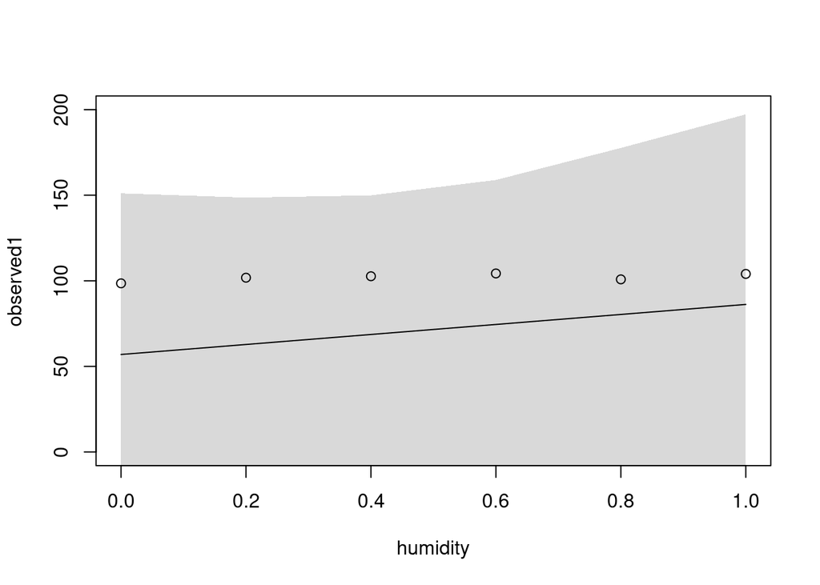

```r
plot(observed1~humidity,ylim=c(0,200), data=sc1data)
lines(sc1data$humidity , yexpmeansc1)
shade(yexpPIsc1 , sc1data$humidity)
```

# Solution and example 2

OK, so we don’t have enough data to estimate all sigmam values. Perhaps we can help ourselves by assuming that all the sigmam values are the same.

```r
sc1ssmodel=alist(
  observed1 ~ dnorm(realsize[id], sigmam),
  realsize[id] ~ dnorm(mu, sigma),
  mu <- alpha + beta*humidity,

  sigma ~ dunif(0,1000),
  sigmam ~ dunif(0,1000),
  alpha ~ dnorm(0, 100),
  beta ~ dnorm(0,100)

)
```

And fit it.

```r
sc1ssposterior=ulam(sc1ssmodel,
                 data=sc1data,iter = 5000)
```

We see that the precision of estimates improved dramatically.

```r
precis(sc1ssposterior) # single sigmam
```

```
## 6 vector or matrix parameters hidden. Use depth=2 to show them.
```

```
##             mean       sd       5.5%      94.5%     n_eff     Rhat
## sigma   2.601222 3.257006  0.3026153   7.406279  59.74638 1.064101
## sigmam  2.585621 2.684668  0.3883957   6.578516 143.59600 1.027704
## alpha  99.958469 3.692693 95.0616155 104.749125 708.21040 1.000256
## beta    3.942711 6.690248 -3.8082997  12.137216 735.10580 1.001617
```

```r
precis(sc1posterior) # multiple sigmam
```

```
## 12 vector or matrix parameters hidden. Use depth=2 to show them.
```

```
##           mean        sd      5.5%    94.5%     n_eff     Rhat
## sigma 83.54497 105.20424   3.01515 272.5267  72.46944 1.018030
## alpha 56.95221  63.97188 -53.07162 151.1024 732.17392 1.002491
## beta  29.24508  75.96837 -96.85447 140.3897 248.68293 1.012958
```

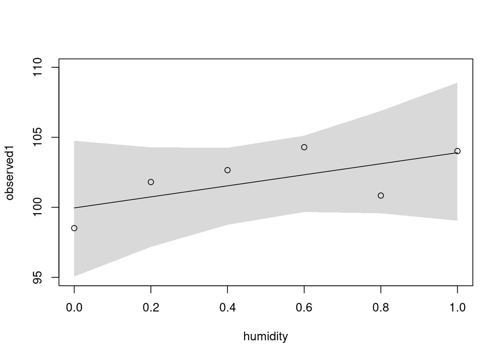

```r
yexpsc1ss=link(sc1ssposterior)

yexpmeansc1ss=apply(yexpsc1ss,2, mean)
yexpPIsc1ss=apply(yexpsc1ss,2, PI)

plot(observed1~humidity, data=sc1data, ylim=c(95,110))
lines(sc1data$humidity , yexpmeansc1ss)
shade(yexpPIsc1ss , sc1data$humidity)
```

# Solution and example 3

Alternatively, we can also directly advise the model on our prior expectation what sigmam is. For instance we know based on previous experience that it is between 1 and 3.

```r
sc1rpmodel=alist(
  observed1 ~ dnorm(realsize[id], sigmam[id]),
  realsize[id] ~ dnorm(mu, sigma),
  mu <- alpha + beta*humidity,

  sigma ~ dunif(0,1000),
  sigmam[id] ~ dunif(1,3),
  alpha ~ dnorm(0, 100),
  beta ~ dnorm(0,100)

)
```

And fit it.

```r
sc1rpposterior=ulam(sc1rpmodel,
                 data=sc1data,iter = 5000)
```

We see that the precision of estimates improved even more.

```r
precis(sc1rpposterior) # restrictive prior
```

```
## 12 vector or matrix parameters hidden. Use depth=2 to show them.
```

```
##             mean       sd       5.5%      94.5%    n_eff      Rhat
## sigma   2.113789 2.063298  0.3514315   5.364135 409.3269 0.9996032
## alpha 100.265674 2.383870 96.8270709 103.828776 823.6835 0.9996319
## beta    3.686767 4.284036 -2.1740816   9.555853 728.6178 1.0006649
```

```r
precis(sc1ssposterior) # single sigmam
```

```
## 6 vector or matrix parameters hidden. Use depth=2 to show them.
```

```
##             mean       sd       5.5%      94.5%     n_eff     Rhat
## sigma   2.601222 3.257006  0.3026153   7.406279  59.74638 1.064101
## sigmam  2.585621 2.684668  0.3883957   6.578516 143.59600 1.027704
## alpha  99.958469 3.692693 95.0616155 104.749125 708.21040 1.000256
## beta    3.942711 6.690248 -3.8082997  12.137216 735.10580 1.001617
```

```r
precis(sc1posterior) # multiple sigmam
```

```
## 12 vector or matrix parameters hidden. Use depth=2 to show them.
```

```
##           mean        sd      5.5%    94.5%     n_eff     Rhat
## sigma 83.54497 105.20424   3.01515 272.5267  72.46944 1.018030
## alpha 56.95221  63.97188 -53.07162 151.1024 732.17392 1.002491
## beta  29.24508  75.96837 -96.85447 140.3897 248.68293 1.012958
```

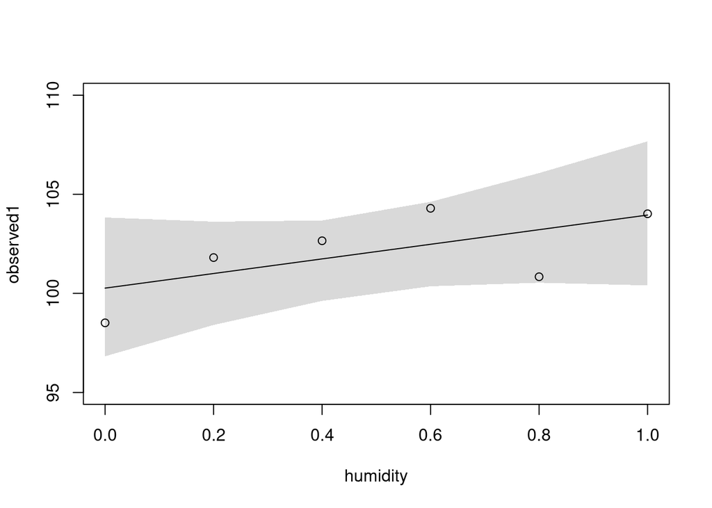

```r
yexpsc1rp=link(sc1rpposterior)

yexpmeansc1rp=apply(yexpsc1rp,2, mean)
yexpPIsc1rp=apply(yexpsc1rp,2, PI)

plot(observed1~humidity, data=sc1data,ylim=c(95,110))
lines(sc1data$humidity , yexpmeansc1rp)
shade(yexpPIsc1rp , sc1data$humidity)
```

# Trick question

What if we wanted to hardwire sigmam to 2?

# No replacement for displacement amount of data

[figure not shown]

The less sophisticated model with a lot of data may simply perform better. But not much better in fact.

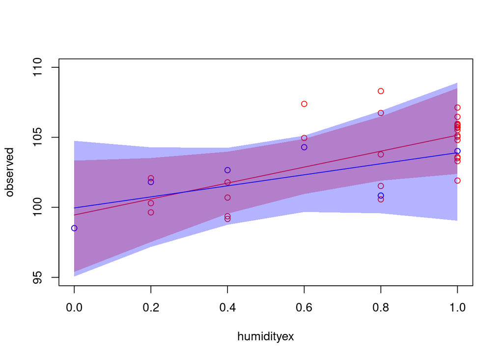

```r
plot(observed~humidityex, data=scdata, col="red", ylim=c(95,110))
points(observed1~humidity, data=sc1data, col="blue")

lines(scdata$humidity , yexpmeansc, col="red")
shade(yexpPIsc , scdata$humidity, col=alpha("red", alpha=0.3))

lines(sc1data$humidity , yexpmeansc1ss, col="blue")
shade(yexpPIsc1ss , sc1data$humidity, col=alpha("blue", alpha=0.3))
```